# Notebook

### Web Information Retrieval and Data Mining - Assignment 3

```
Student: van Dooren, Bart (1006262)
```

#### Answer 1.1, Baseline (4p)

- Dense network, at least 3 layers, shaped like a pyramid
  - Last layer: 10 nodes, sigmoid.
  - Loss: categorical cross-entropy. Metric: accuracy
- No preprocessing, regularization. Get at least 70% accuracy.
- Explain design decisions. Discuss performance.
  - Does it overfit (large/growing gap between loss and val_loss)?

[output not shown]

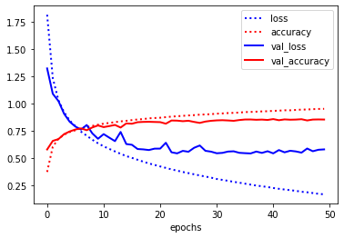

```
Model: "sequential_2"
_________________________________________________________________
Layer (type)                 Output Shape              Param #
=================================================================
reshape_2 (Reshape)          (None, 3072)              0
_________________________________________________________________
dense_6 (Dense)              (None, 1536)              4720128
_________________________________________________________________
dense_7 (Dense)              (None, 768)               1180416
_________________________________________________________________
dense_8 (Dense)              (None, 200)               153800
_________________________________________________________________
dense_9 (Dense)              (None, 10)                2010
=================================================================
Total params: 6,056,354
Trainable params: 6,056,354
Non-trainable params: 0
_________________________________________________________________
None
def build_model_1_1():
    # Create Sequential model
    model = models.Sequential()

    # Reshape the input
    model.add(layers.Reshape((3072,), input_shape=(32,32,3)))

    # Add dense layers to model
    model.add(layers.Dense(1536, activation='relu'))
    model.add(layers.Dense(768, activation='relu'))
    model.add(layers.Dense(200, activation='relu'))
    # Add softmax output layer
    model.add(layers.Dense(10, activation='softmax'))

    # Compile the model
    model.compile(optimizer=optimizers.Adagrad(lr=0.01),
                  loss='categorical_crossentropy',
                  metrics=['accuracy'])
    # Return the model
    return model
```

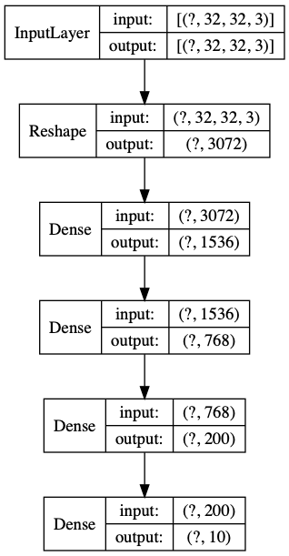

#### Answer 1.2, Preprocess (2p)

- Convert images to greyscale, other preprocessing optional.
  - Input shape should be (32,32,1)
- Explain design decisions. Is it better? Why (not)?
  - Color information is likely not so useful for classification. Greyscale makes the network smaller, less parameters to learn, less likely to overfit.

[output not shown]

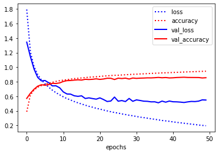

```
Model: "sequential_3"
_________________________________________________________________
Layer (type)                 Output Shape              Param #
=================================================================
reshape_3 (Reshape)          (None, 1024)              0
_________________________________________________________________
dense_10 (Dense)             (None, 1536)              1574400
_________________________________________________________________
dense_11 (Dense)             (None, 768)               1180416
_________________________________________________________________
dense_12 (Dense)             (None, 200)               153800
_________________________________________________________________
dense_13 (Dense)             (None, 10)                2010
=================================================================
Total params: 2,910,626
Trainable params: 2,910,626
Non-trainable params: 0
_________________________________________________________________
None
def build_model_1_2():
    # Create Sequential model
    model = models.Sequential()

    # Reshape the input based on gray-scaled images
    model.add(layers.Reshape((1024,), input_shape=(32,32,1)))

    # Add dense layers to model
    model.add(layers.Dense(1536, activation='relu'))
    model.add(layers.Dense(768, activation='relu'))
    model.add(layers.Dense(200, activation='relu'))
    # Add softmax output layer
    model.add(layers.Dense(10, activation='softmax'))

    # Compile the model
    model.compile(optimizer=optimizers.Adagrad(lr=0.01),
                  loss='categorical_crossentropy',
                  metrics=['accuracy'])

    # Return the model
    return model
```

#### Answer 1.3, Tune (4p)

- Regularize the model. What works best?
  - Should consider batch normalization, dropout, l1/l2 regularization (or Nesterov)
- Tune other hyperparameters (e.g. learning rate, batch size,...) as you see fit.
  - At least consider tuning learning rate, ideally also momentum, decay, other optimizers
- Explain your findings and final design decisions. Discuss the results.
  - Should be better, at least it shouldn't overfit

[output not shown]

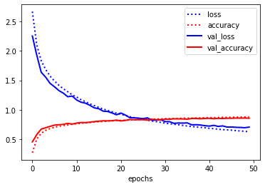

```
def build_model_1_3():
    # Create Sequential model
    model = models.Sequential()

    # Reshape the input based on gray-scaled images
    model.add(layers.Reshape((1024,), input_shape=(32,32,1)))

    # Add dense layers to model and dropout with BatchNormalization
    model.add(layers.Dense(1536, kernel_regularizer=regularizers.l2(0.00025), activation='relu'))
    model.add(layers.Dense(768, kernel_regularizer=regularizers.l2(0.00025), activation='relu'))
    model.add(layers.Dropout(0.2))
    model.add(layers.Dense(200, kernel_regularizer=regularizers.l2(0.00025), activation='relu'))
    model.add(layers.Dropout(0.5))
    # Add softmax output layer
    model.add(layers.Dense(10, activation='softmax'))

    # Compile the model
    model.compile(optimizer=optimizers.Adagrad(lr=0.01),
                  loss='categorical_crossentropy',
                  metrics=['accuracy'])
    # Return model
    return model
```

#### Answer 2.1, ConvNet (7p)

- Build a sequential ConvNet, get at least 90% accuracy.
  - Conv2D layers, input shape (32,32,1)
  - Consider using blocks of Conv2D layers with maxpooling in between
  - Use zero-padding in Conv2D layers because the images are small
  - At least one dense hidden layer and dense output layer (sigmoid)
  - Consider adding batch normalization, dropout
  - Consider small dropout rates in beginning, larger dropout rates later in network
  - Consider other optimizers and tuning learning rate, momentum,...
- Explain what you did and why (800 chars). Is it working well?
  - Should be quite elaborate and sensible

[output not shown]

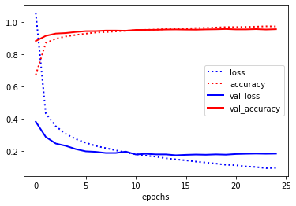

```
Model: "sequential_54"
_________________________________________________________________
Layer (type)                 Output Shape              Param #
=================================================================
conv2d_48 (Conv2D)           (None, 32, 32, 32)        544
_________________________________________________________________
batch_normalization_67 (Batc (None, 32, 32, 32)        128
_________________________________________________________________
conv2d_49 (Conv2D)           (None, 32, 32, 32)        16416
_________________________________________________________________
batch_normalization_68 (Batc (None, 32, 32, 32)        128
_________________________________________________________________
max_pooling2d_19 (MaxPooling (None, 16, 16, 32)        0
_________________________________________________________________
dropout_86 (Dropout)         (None, 16, 16, 32)        0
_________________________________________________________________
conv2d_50 (Conv2D)           (None, 16, 16, 64)        32832
_________________________________________________________________
batch_normalization_69 (Batc (None, 16, 16, 64)        256
_________________________________________________________________
conv2d_51 (Conv2D)           (None, 16, 16, 64)        65600
_________________________________________________________________
batch_normalization_70 (Batc (None, 16, 16, 64)        256
_________________________________________________________________
max_pooling2d_20 (MaxPooling (None, 8, 8, 64)          0
_________________________________________________________________
dropout_87 (Dropout)         (None, 8, 8, 64)          0
_________________________________________________________________
conv2d_52 (Conv2D)           (None, 8, 8, 200)         205000
_________________________________________________________________
batch_normalization_71 (Batc (None, 8, 8, 200)         800
_________________________________________________________________
conv2d_53 (Conv2D)           (None, 8, 8, 200)         640200
_________________________________________________________________
batch_normalization_72 (Batc (None, 8, 8, 200)         800
_________________________________________________________________
max_pooling2d_21 (MaxPooling (None, 4, 4, 200)         0
_________________________________________________________________
dropout_88 (Dropout)         (None, 4, 4, 200)         0
_________________________________________________________________
```

[output cut: 38 more lines]

```
  model.add(layers.Flatten())
  model.add(layers.Dense(200, activation='relu'))
  model.add(layers.BatchNormalization())
  model.add(layers.Dropout(0.5))

  # Add softmax output layer
  model.add(layers.Dense(10, activation='softmax'))

  # Compile the model
  model.compile(optimizer=optimizers.Adagrad(lr=0.01),
              loss='categorical_crossentropy',
              metrics=['accuracy'])

  # Return model
  return model
```

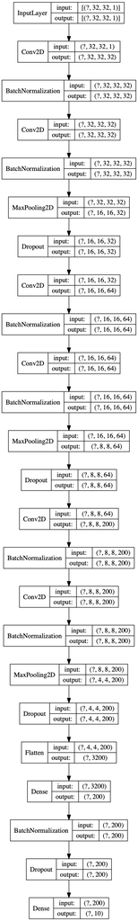

#### Answer 2.2, Data Augmentation (3p)

- Augment the preprocessed training data.
  - Use small variations (small shifts up-down, left-right) of flips becasue the images are small
  - Large shifts and rotations distort the image too much
- Explain what you did and why. Discuss the performance of the model.

[output not shown]

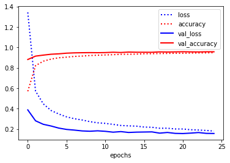

```
train_datagen = ImageDataGenerator(
    rotation_range= 10,
    width_shift_range=0.1,
    height_shift_range=0.1,
    zoom_range=[1,1.25])
```

#### Answer 3.1, Misclassifications (2p)

[output not shown]

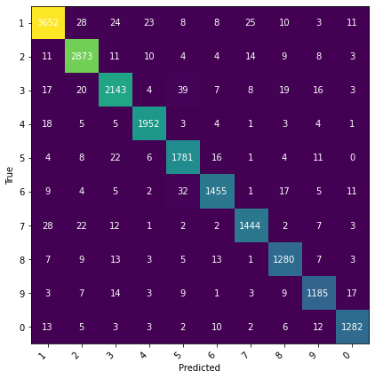

[figure not shown]

#### Answer 3.2, Activations (4p)

- Retrieve and visualize the activations for one example
- For every filter for different convolutional layers (at different depths in the network).
- Give an explanation. Is your model indeed learning something useful?
  - Should detect edges etc in first layers, higher-order object (e.g. interesting regions) in deeper layers.

[output not shown]

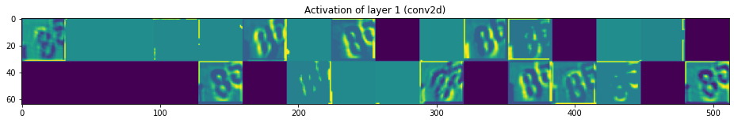

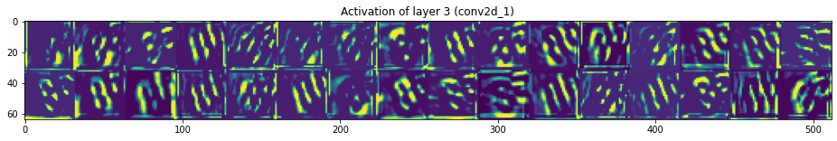

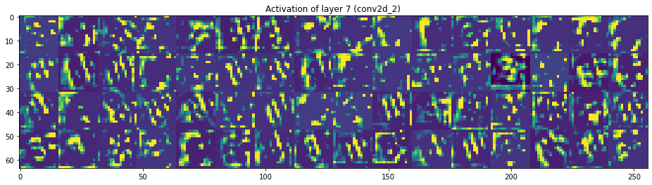

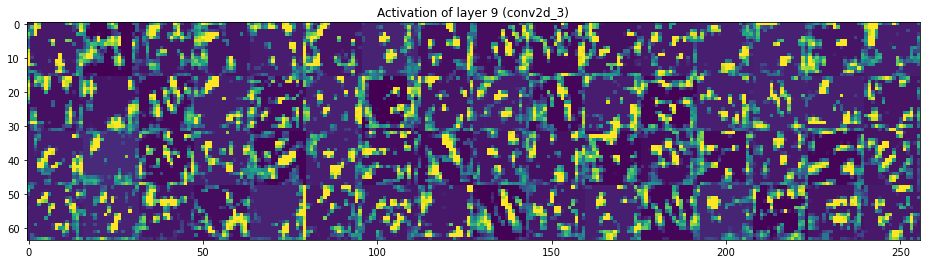

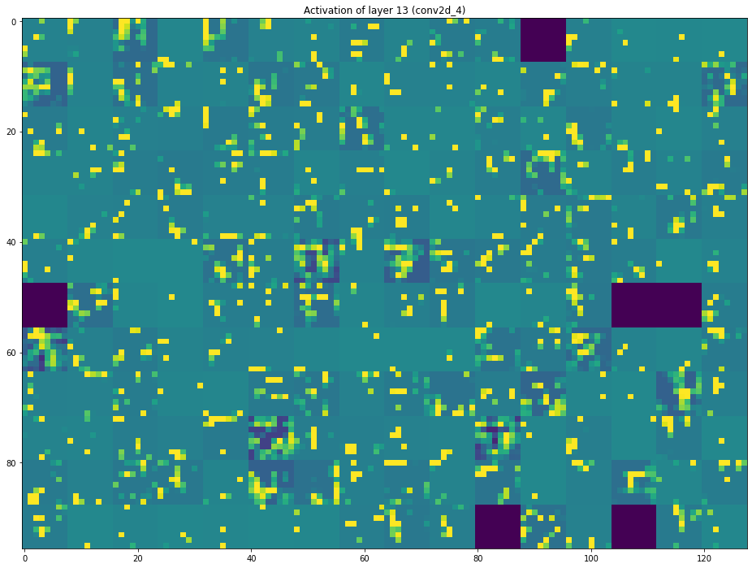

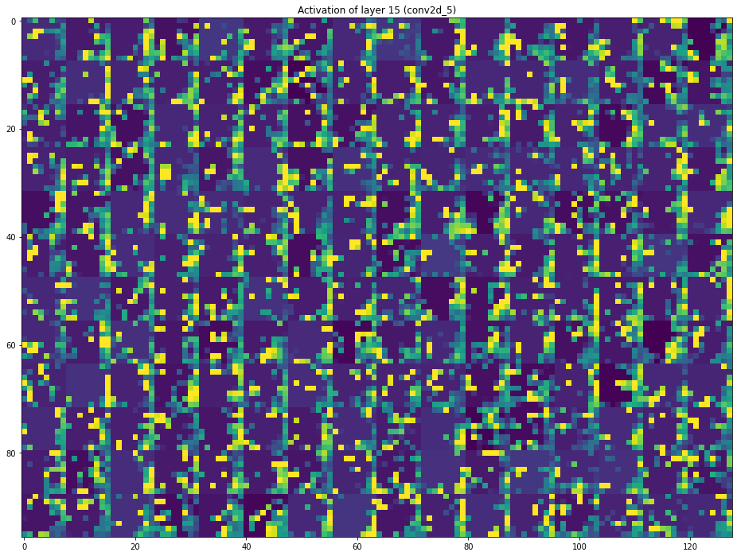

#### Answer 3.3, Class activation map (4p)

- Show a class activation map for your last convolutional layer
- Superimpose the activation map over the image, or plot side by side
  - Should make sense, detect interesting regions to classify the number

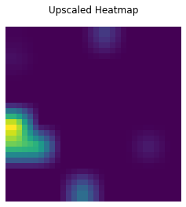

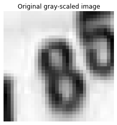

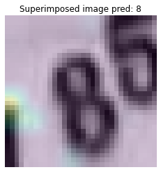

```
def plot_3_3():
  K.clear_session()

  # Load model 2_2
  model = load_model_from_file(base_dir, "model_2_2", extension='.h5')


  X_testGray = rgb2gray(X_test)

  # Do model prediction to get prediction of first image
  preds = model.predict(X_testGray)

  # Get predictions labels
  predictionsLabels = [(np.argmax(entry)+1)%10 for entry in preds]

  # Get gray-scaled image
  img_tensor = X_testGray[0]

  img_tensor = np.expand_dims(img_tensor, axis=0)

  # Get last conv layer conv2d_5
  last_conv_layer = model.get_layer('conv2d_5')

  first_output = model.output[:, 0]

  grads = K.gradients(first_output, last_conv_layer.output)[0]

  # Generate pooled grad values
  pooled_grads = K.mean(grads, axis=(0, 1, 2))

  # given a sample image
  iterate = K.function([model.input], [pooled_grads, last_conv_layer.output[0]])
  pooled_grads_value, conv_layer_output_value = iterate([img_tensor])

  # for loop of 200, as this is the specified value for the last layer
  for i in range(200):
    conv_layer_output_value[:, :, i] *= pooled_grads_value[i]

  # Generate heatmap
  heatmap = np.mean(conv_layer_output_value, axis=-1)
```

[output cut: 19 more lines]

```
  # Show gray-scaled image
  fig = plt.figure(frameon=False)
  img_tensor = np.resize(img_tensor, (32,32))
  plt.imshow(img_tensor, cmap=plt.cm.gray)
  plt.title('Original gray-scaled image')
  plt.axis('off')
  plt.show()

  # Generate super imposed image
  im1 = plt.imshow(img_tensor, cmap=plt.cm.gray, interpolation='nearest')
  res = predictionsLabels[0].astype(str)
  im2 = plt.imshow(heatmap, cmap=plt.cm.viridis, alpha=.25, interpolation='bilinear')
  plt.title('Superimposed image pred: ' + res)
  plt.axis('off')
  plt.show()
```

#### Answer 4.1, Fast feature extraction (5p)

- Import the VGG16 model, pretrained on ImageNet
- Freeze convolutional base, adds a dense layer
- Consider unfreezing the last few convolutional layers and evaluate whether that works better
  - Check if they do. It is very likely to help.
- Discuss the observed performance
  - Should get around 80% accuracy

[output not shown]

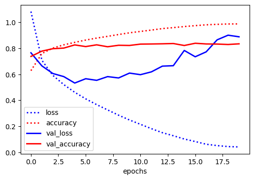

```
Model: "model_23"
_________________________________________________________________
Layer (type)                 Output Shape              Param #
=================================================================
input_23 (InputLayer)        [(None, 32, 32, 3)]       0
_________________________________________________________________
block1_conv1 (Conv2D)        (None, 32, 32, 64)        1792
_________________________________________________________________
block1_conv2 (Conv2D)        (None, 32, 32, 64)        36928
_________________________________________________________________
block1_pool (MaxPooling2D)   (None, 16, 16, 64)        0
_________________________________________________________________
block2_conv1 (Conv2D)        (None, 16, 16, 128)       73856
_________________________________________________________________
block2_conv2 (Conv2D)        (None, 16, 16, 128)       147584
_________________________________________________________________
block2_pool (MaxPooling2D)   (None, 8, 8, 128)         0
_________________________________________________________________
block3_conv1 (Conv2D)        (None, 8, 8, 256)         295168
_________________________________________________________________
block3_conv2 (Conv2D)        (None, 8, 8, 256)         590080
_________________________________________________________________
block3_conv3 (Conv2D)        (None, 8, 8, 256)         590080
_________________________________________________________________
block3_pool (MaxPooling2D)   (None, 4, 4, 256)         0
_________________________________________________________________
block4_conv1 (Conv2D)        (None, 4, 4, 512)         1180160
_________________________________________________________________
block4_conv2 (Conv2D)        (None, 4, 4, 512)         2359808
_________________________________________________________________
block4_conv3 (Conv2D)        (None, 4, 4, 512)         2359808
_________________________________________________________________
block4_pool (MaxPooling2D)   (None, 2, 2, 512)         0
_________________________________________________________________
block5_conv1 (Conv2D)        (None, 2, 2, 512)         2359808
_________________________________________________________________
block5_conv2 (Conv2D)        (None, 2, 2, 512)         2359808
_________________________________________________________________
block5_conv3 (Conv2D)        (None, 2, 2, 512)         2359808
_________________________________________________________________
```

[output cut: 27 more lines]

```
  model = Model(inputs=base_model.input, outputs=predictions)
  # Determine which layers to freeze
  for layer in model.layers:
      # Freeze all layers
      layer.trainable = False
      if layer.name == 'block5_conv1' or layer.name == 'block5_conv2' or layer.name == 'block5_conv3' or layer.name == 'block5_pool' or ('dense' in layer.name) or ('flatten' in layer.name):
          # Unfreeze a layer
          layer.trainable = True

  # Compile the model
  model.compile(optimizer=optimizers.Adagrad(lr=0.01),
            loss='categorical_crossentropy',
            metrics=['accuracy'])
  # Return the model
  return model
```

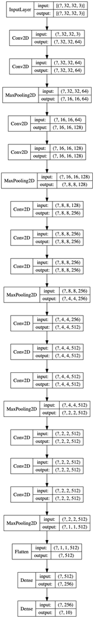

#### Answer 4.2, Embeddings (5p)

- Generate embeddings with the trained convolutional part of model_4_1 (without the dense layer)
- Embed the training and test data and store them to disk
- Build and evaluate a pipeline on the embedded data
  - Check if pipeline makes sense (e.g. use models that can handle many dimensions)
- Describe what you did and what you observed (max 800 chars).
  - Consider different models, preprocessing, tuning, etc.
  - Check performance (see original Submission.html) when in doubt. We did not run all the evaluations because it takes too long, and the output is ill-defined.

[output not shown]

```
Running time: 165.35 seconds
Last modified: May 29, 2020
scikit-learn version: 0.23.1
```